# Praca domowa 2

Ignacy Stępniewski

## Dane

Dane wykorzystane w Pracy domowej 2 dotyczą wyników egzaminów z 3 umiejętności: czytania, pisania i operacji matematycznych. Dodatkowo dostępne są podstawowe informacje o studentach i ich rodzicach. Opis wszystkich kolumn znajduje się również w pliku `README.md`.

| Zmienna | Opis |
| --- | --- |
| **gender** | płeć |
| **race.ethnicity** | pochodzenie etniczne |
| **parental.level.of.education** | wykształcenie rodziców |
| **lunch** | jaki obiad jedli uczniowie w dniu egzaminu |
| **test.preparation.course** | czy uczeń odbył kurs przygotowujący |
| **math.score** | wynik egzaminu z matematyki |
| **reading.score** | wynik egzaminu z czytania |
| **writing.score** | wynik egzaminu z pisania |

## Zadanie 1

Jak wyglądają rozkłady wyników uczniów z trzech przedmiotów (matematyka, czytanie, pisanie)?

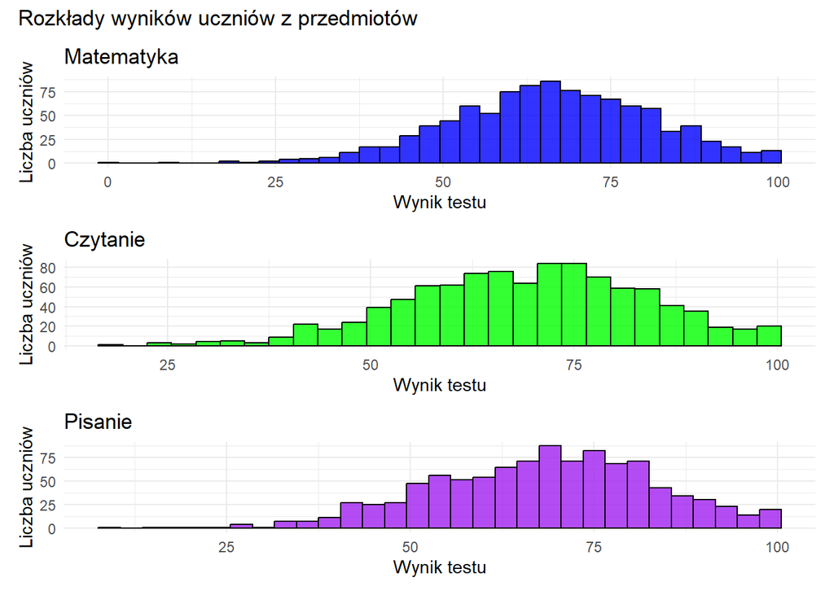

```r
# Tu umieść kod do wygenerowania odpowiedzi do zadania.
p_math <- ggplot(df, aes(x = math.score)) +
  geom_histogram(binwidth = 3, fill = "blue", color = "black", alpha = 0.8) +
  labs(title = "Matematyka", x = "Wynik testu", y = "Liczba uczniów") +
  theme_minimal()

p_reading <- ggplot(df, aes(x = reading.score)) +
  geom_histogram(binwidth = 3, fill = "green", color = "black", alpha = 0.8) +
  labs(title = "Czytanie", x = "Wynik testu", y = "Liczba uczniów") +
  theme_minimal()

p_writing <- ggplot(df, aes(x = writing.score)) +
  geom_histogram(binwidth = 3, fill = "purple", color = "black", alpha = 0.8) +
  labs(title = "Pisanie", x = "Wynik testu", y = "Liczba uczniów") +
  theme_minimal()

(p_math / p_reading / p_writing) +
  plot_annotation(title = "Rozkłady wyników uczniów z przedmiotów")
```

## Zadanie 2

Czy istnieje zauważalna różnica w wynikach między uczniami i uczennicami?

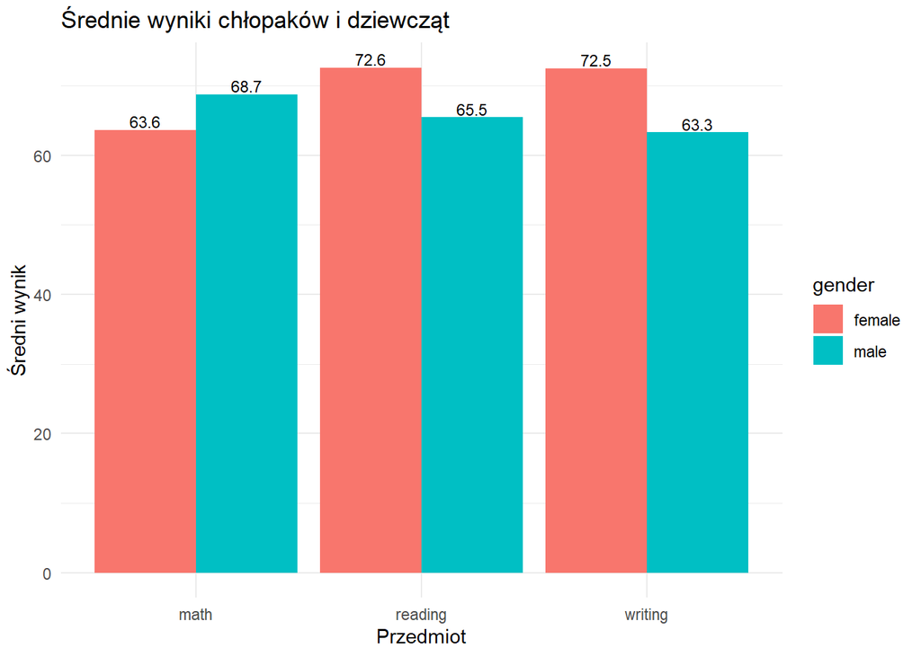

```r
# Tu umieść kod do wygenerowania odpowiedzi do zadania.
means <- df %>%
  group_by(gender) %>%
  summarise(
    math = mean(math.score),
    reading = mean(reading.score),
    writing = mean(writing.score),
    .groups = 'drop'
  )

means_long <- rbind(
  data.frame(subject = 'math',    gender = means$gender, mean_score = means$math),
  data.frame(subject = 'reading', gender = means$gender, mean_score = means$reading),
  data.frame(subject = 'writing', gender = means$gender, mean_score = means$writing)
)

ggplot(means_long, aes(x = subject, y = mean_score, fill = gender)) +
  geom_col(position = 'dodge') +
  geom_text(aes(label = round(mean_score, 1)),
            position = position_dodge(width = 0.9),
            vjust = -0.2,
            size = 3) +
  labs(
    title = 'Średnie wyniki chłopaków i dziewcząt',
    x = 'Przedmiot',
    y = 'Średni wynik'
  ) +
  theme_minimal()
```

**Komentarz: Istnieje zayuważalna różnica w wynikach w zależności od płci, dziewczęta radzą sobie sporo lepiej od chłopaków w pisaniu (różnica 9.2 pkt) a także (choć trochę mniej bo 7.1 pkt różnicy) w czytaniu, natomiast chłopcy są średnio trochę lepsi w matematyce (różnica 5.1 pkt)**

## Zadanie 3

Czy uczniowie, którzy ukończyli kurs przygotowawczy, osiągają lepsze wyniki niż pozostali?

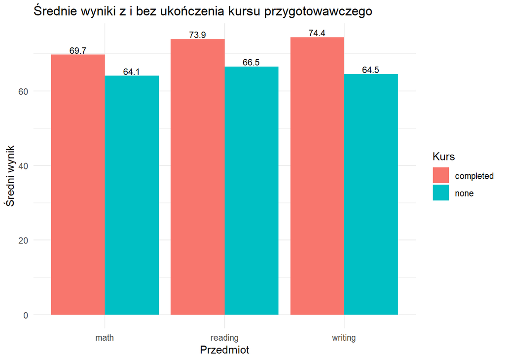

```r
# Tu umieść kod do wygenerowania odpowiedzi do zadania.
means <- df %>%
  group_by(test.preparation.course) %>%
  summarise(
    math = mean(math.score),
    reading = mean(reading.score),
    writing = mean(writing.score),
    .groups = 'drop'
  )

means_long <- rbind(
  data.frame(
    subject = 'math',
    test.preparation.course = means$test.preparation.course,
    mean_score = means$math
  ),
  data.frame(
    subject = 'reading',
    test.preparation.course = means$test.preparation.course,
    mean_score = means$reading
  ),
  data.frame(
    subject = 'writing',
    test.preparation.course = means$test.preparation.course,
    mean_score = means$writing
  )
)

ggplot(means_long,
       aes(x = subject, y = mean_score, fill = test.preparation.course)) +
  geom_col(position = 'dodge') +
  geom_text(aes(label = round(mean_score, 1)),
            position = position_dodge(width = 0.9),
            vjust = -0.2,
            size = 3) +
  labs(
    title = 'Średnie wyniki z i bez ukończenia kursu przygotowawczego',
    x = 'Przedmiot',
    y = 'Średni wynik',
    fill = 'Kurs'
  ) +
  theme_minimal()
```

**Komentarz: Tak, uczniowie którzy ukończyli kurs przygotowawczy radzą sobie średnio lepiej od tych którzy tego nie zrobili, największą poprawę (bo różnica wynosi aż 9.9pkt) widać w pisaniu, potem w czytaniu (7.4pkt) i matematyce (5.6pkt)**

## Zadanie 4

Jaki jest związek między poziomem wykształcenia rodziców a średnimi wynikami uczniów?

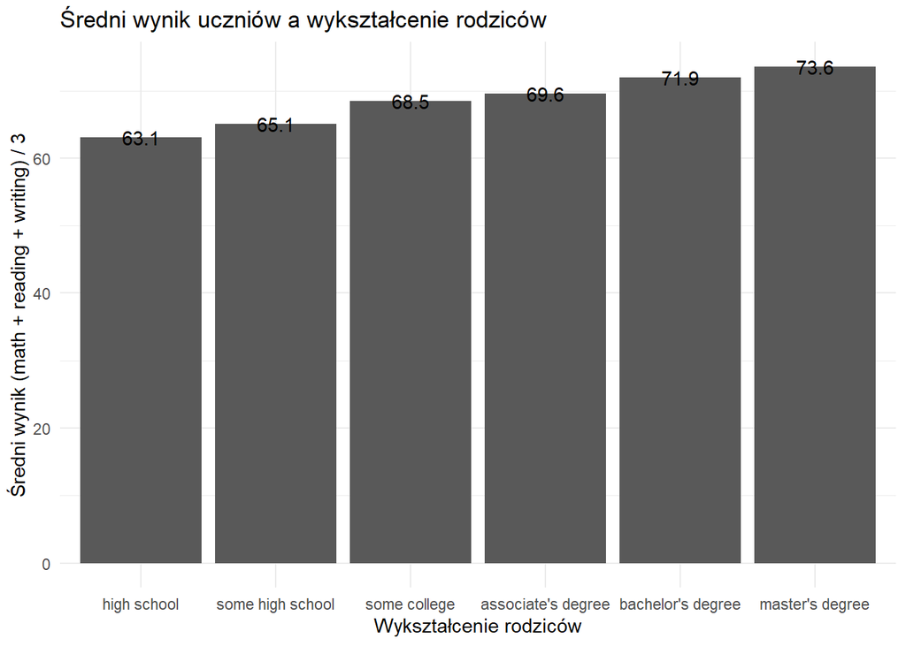

```r
# Tu umieść kod do wygenerowania odpowiedzi do zadania.
means <- df %>%
  group_by(parental.level.of.education) %>%
  summarise(
    mean_math = mean(math.score),
    mean_reading = mean(reading.score),
    mean_writing = mean(writing.score),
    mean_total = (mean_math + mean_reading + mean_writing) / 3,
    .groups = 'drop'
  )

ggplot(
  means,
  aes(x = reorder(parental.level.of.education, mean_total),
      y = mean_total)
) +
  geom_col() +
  geom_text(aes(label = round(mean_total, 1))) +
  labs(
    title = 'Średni wynik uczniów a wykształcenie rodziców',
    x = 'Wykształcenie rodziców',
    y = 'Średni wynik (math + reading + writing) / 3'
  ) +
  theme_minimal()
```

## Zadanie 5

Czy płeć i wykształcenie rodzica wpływa na wynik z matematyki?

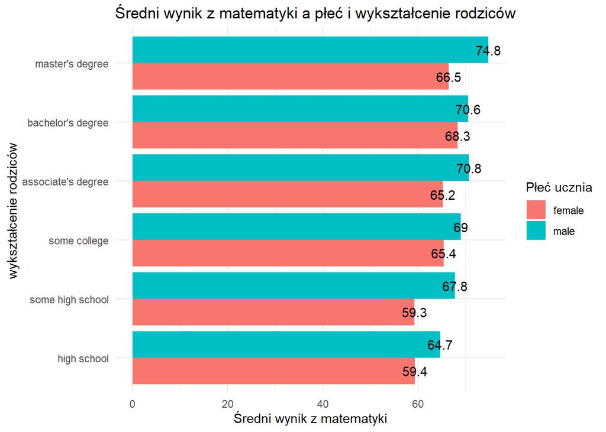

```r
# Tu umieść kod do wygenerowania odpowiedzi do zadania.
means <- df %>%
  group_by(parental.level.of.education, gender) %>%
  summarise(
    mean_math = mean(math.score),
    .groups = 'drop'
  )

ggplot(
  means,
  aes(
    x = reorder(parental.level.of.education, mean_math),
    y = mean_math,
    fill = gender
  )
) +
  geom_col(position = 'dodge') +
  geom_text(
    aes(label = round(mean_math, 1)),
    position = position_dodge(width = 0.9),
  ) +
  coord_flip() +
  labs(
    title = 'Średni wynik z matematyki a płeć i wykształcenie rodziców',
    x = 'wykształcenie rodziców',
    y = 'Średni wynik z matematyki',
    fill = 'Płeć ucznia'
  ) +
  theme_minimal()
```

## Zadanie 6 Czy istnieje zależność między wynikami z matematyki a wynikami z czytania lub pisania?

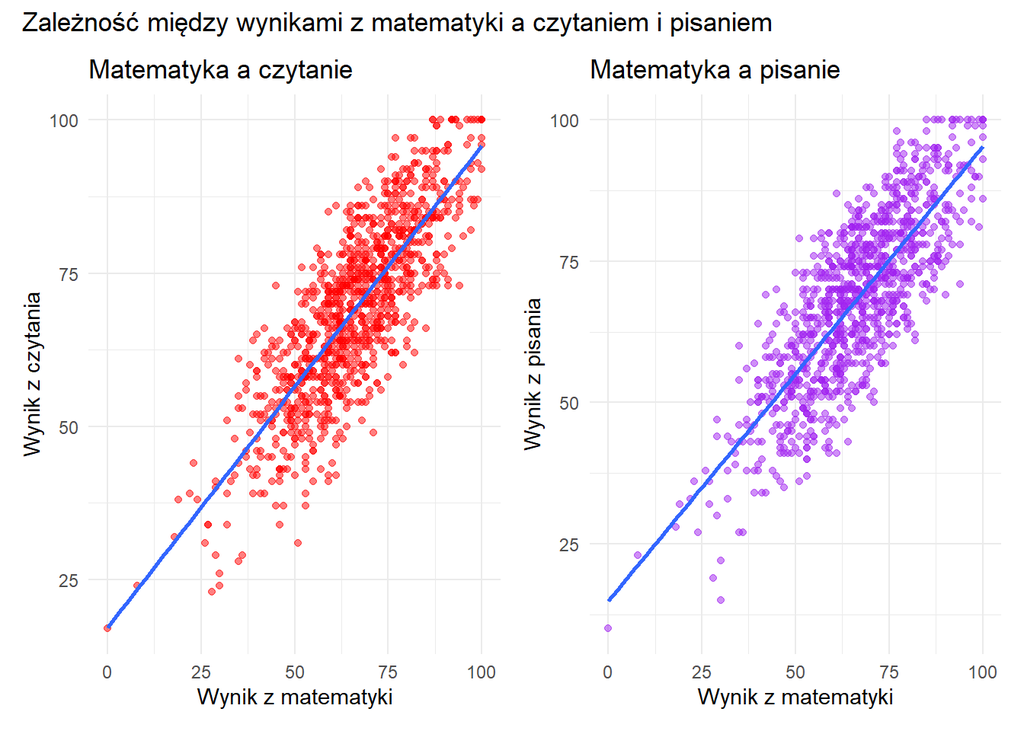

```r
# Tu umieść kod do wygenerowania odpowiedzi do zadania.
p_read <- ggplot(df, aes(x = math.score, y = reading.score)) +
  geom_point(alpha = 0.5, color = 'red') +
  geom_smooth(method = 'lm', se = FALSE) +
  labs(
    title = 'Matematyka a czytanie',
    x = 'Wynik z matematyki',
    y = 'Wynik z czytania'
  ) +
  theme_minimal()

p_write <- ggplot(df, aes(x = math.score, y = writing.score)) +
  geom_point(alpha = 0.5, color = 'purple') +
  geom_smooth(method = 'lm', se = FALSE) +
  labs(
    title = 'Matematyka a pisanie',
    x = 'Wynik z matematyki',
    y = 'Wynik z pisania'
  ) +
  theme_minimal()

p_read + p_write +
  plot_layout(ncol = 2) +
  plot_annotation(title = 'Zależność między wynikami z matematyki a czytaniem i pisaniem')
```

**Komentarz:Na wykresie zdecydowanie widać trend: Uczniowie uzyskujący wyższe wyniki z matematyki uzyskują także wyższe wyniki zarówno z pisania jak i czytania, więc tak, istnieje zależność.**